# STAT/MATH 495: Problem Set 04

Anthony Rentsch

2017-10-03

# Collaboration

I worked alone on this problem set.

# Load packages, data, model formulas

```r
credit <- read.csv("http://www-bcf.usc.edu/~gareth/ISL/Credit.csv") %>%
  mutate(ID = 1:n()) %>%
  select(ID, Balance, Income, Limit, Rating, Age, Cards, Education)
```

You will train the following 7 models on `credit_train`…

```r
model1_formula <- as.formula("Balance ~ 1")
model2_formula <- as.formula("Balance ~ Income")
model3_formula <- as.formula("Balance ~ Income + Limit")
model4_formula <- as.formula("Balance ~ Income + Limit + Rating")
model5_formula <- as.formula("Balance ~ Income + Limit + Rating + Age")
model6_formula <- as.formula("Balance ~ Income + Limit + Rating + Age + Cards")
model7_formula <- as.formula("Balance ~ Income + Limit + Rating + Age + Cards + Education")
```

… where `credit_train` is defined below, along with `credit_test`.

```r
set.seed(79)
credit_train <- credit %>%
  sample_n(20)
credit_test <- credit %>%
  anti_join(credit_train, by="ID")
```

# RMSE vs number of coefficients

```r
# Store all model formulas in a list
models <- c(model1_formula,
            model2_formula,
            model3_formula,
            model4_formula,
            model5_formula,
            model6_formula,
            model7_formula)

# Create a function to calculate RMSE
calculateRMSE <- function(obs, preds) sqrt(mean((obs - preds)^2))

# Loop through each model formula, train model, and calculate RMSE for training and test sets
i <- 1
while(i <= 7){
  # Train model
  this.model <- lm(models[[i]], data = credit_train)

  # Calculate RMSE for training set
  RMSE_train[i] <- calculateRMSE(credit_train$Balance, this.model$fitted.values)

  # Use model to make predictions for test set and calculate RMSE
  new_data <- as.data.frame(credit_test)
  preds <- predict(this.model, new_data)
  preds <- as.data.frame(preds)
  preds <- cbind(preds, obs = credit_test$Balance)
  RMSE_test[i] <- calculateRMSE(preds$obs, preds$preds)

  # Iterate
  i = i + 1
}
```

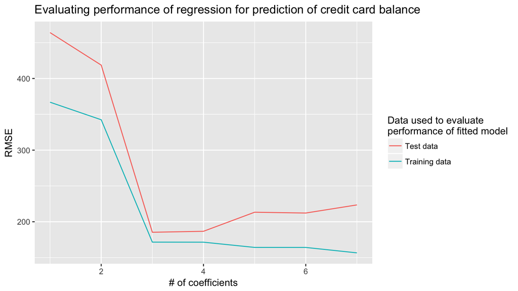

# Interpret the graph

These lines also suggest that any model with less than 2 predictors (3 coefficients) will suffer from underfitting.

# Bonus

Repeat the whole process, but let `credit_train` be a random sample of size 380 from `credit` instead of 20. Now compare and contrast this graph with the one above and hypothesize as to the root cause of any differences.

```r
# Resample from credit, but specify that training set should have 380 observations, not 20
set.seed(66)
credit_train_new <- credit %>%
  sample_n(380)
credit_test_new <- credit %>%
  anti_join(credit_train_new, by="ID")
```

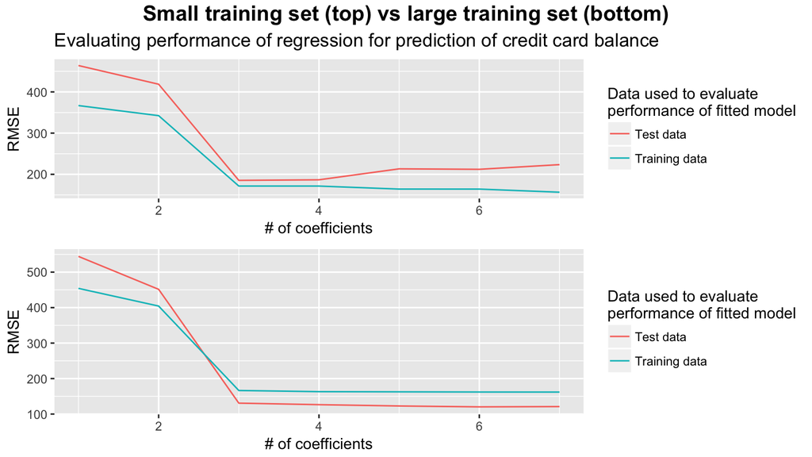

For a large training set we see that the two lines are a bit different. While for less than 3 coefficients in our model the out-of-sample RMSE is still higher than the in-sample RMSE, the inclusion of the third coefficient reduces the out-of-sample RMSE below the in-sample RMSE. At this point, both lines begin to plateau, suggesting that including subsequent predictors to the model does not greatly increase the model’s predictive ability. But, the problem of overfitting seems less apparent when the training set is comprised of 95% of the data rather than 5%, as the out-of-sample prediction error does not increase when the model contains more predictors.

Again, however, we see that including less than 2 predictors (3 coefficients) in the model leads to underfitting, as indicated by the relatively large values of RMSE when the number of coefficients is less than 3.